# Explore Predictors of COVID-19 Health Disparities

12/02/2020

## Background

- As of December 1, 2020, there are *13,714,024* confirmed COVID-19 cases and *270,532* deaths in the United States
- Older adults and people with underlying medical conditions remain at increased risk
- Other people who need extra precautions: racial and ethnic minority groups; people living in rural communities; people experiencing homelessness e.t.c..
- Data showing that some racial and ethnic minority groups are disproportionately affected by COVID-19

**“Nationally, Black, Hispanic and Native American Cases And Deaths Exceed Their Share Of Population”**–Daniel Wood (NPR)

## Health Disparities

- Differences in health outcomes between population groups closely linked to social,economic, and environmental disadvantage (*Healthy People 2020*)
- **Social determinants of health**
  - Access to educational, economic, job opportunities,
  - Health care access and quality
  - Housing and community design

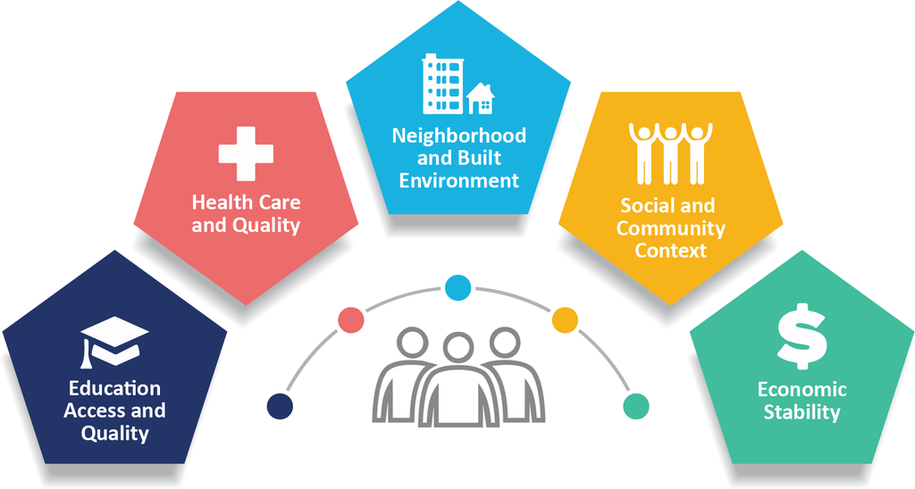

## Methods/Approaches Considered

- State-level COVID-19 cases and deaths (*The COVID Tracking Project*) and state-level data on legislative efforts to preserve or strengthen provisions of the Affordable Care Act (*HealthInsurance.org*)
- Outcome: 1=disparity; 0=no disparity
  - proportion of cases/deaths at least 33% higher than the Census Percentage of Population
  - proportion of cases/deaths elevated whether we include or exclude cases/deaths with unknown race/ethnicity.
  - proportion of cases/deaths based on at least 30 actual cases or deaths
- Features: 36 different measures
- Modeling: Naive Bayes, K nearest neighbors, Decision Tree, Random Forest

## Methods/Approaches Used

- NYT; ACS; County Ranking and Roadmaps; Bureau of Economic Analysis
- Outcome: constructed using NYT and ACS data

**Outcome = % of COVID cases - % of Population**

| Value | Description |
| --- | --- |
| > 0 | Given race/ethnic group experiencing disproportionately high percent of COVID-19 deaths relative to their percent of population |
| = 0 | Given race/ethnic group’ COVID-19 deaths are similar to their percent of the population |
| < 0 | Given race/ethnic group’ COVID-19 deaths are smaller than their percent of the population |

- Features: range from 27 to 42 and cover a range of county characteristics
  - Percentage of households that spend 50% or more of their household income on housing,
  - Percentage of population who are low-income and do not live close to a grocery store,
  - Percentage of population under age 65 without health insurance,
- Modeling techniques
  - Linear Model
  - K-nearest neighbors
  - Bagging
  - Decision Tree
  - Random Forest

## Results

**Attempt 1** (27 features; 702 observations)

- Best model: Random Forest
- Best score after tuning: 156.8

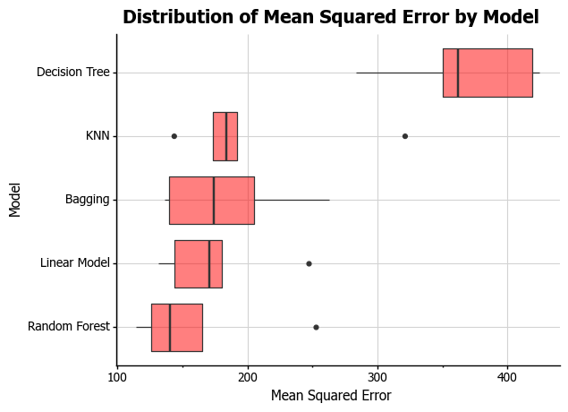

**Attempt 2** (28 features and 663 observations)

- Changed outcome and binned data (cases)
- Best score after tuning Random Forest: 59.10

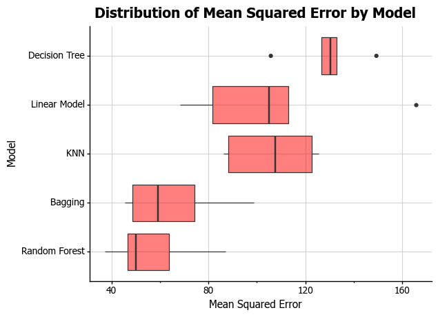

**Attempt 3** (42 features and 701 observations)

- Pre-processing: logged a lot of right skewed data; binned data
- changed outcome variable
- Best score after tuning Random Forest: 0.75

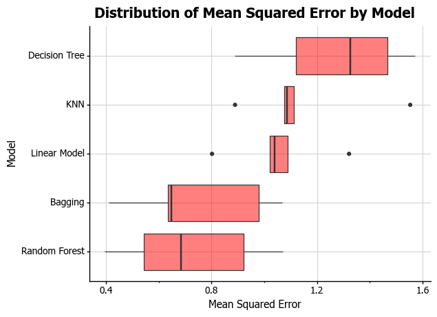

## Variable importance (50 shuffles)

**Top five variables the model relied on most to make its predictions**

| Attempt | Features |
| --- | --- |
| Attempt 1 | Hispanic cases, Black cases, Severe Housing Burden, Uninsured Adults, Hispanic Population, and Black Population |
| Attempt 2 | Black cases, Black Population, Uninsured Adults, Severe Housing Burden, and White Cases |
| Attempt 3 | Black cases, Black Population, Food Insecurity, Uninsured, White Cases |

## Plans to mitigate challenges

- Keep trying different version of outcome variable
- Try imputing missing values
- Consider correlation between variables
- Better features from the Social Vulnerability Index